# Exploration of Coursera-SwiftKey Text Data

Kirsten Meeker

July 22, 2018

Tasks to accomplish

```
1. Exploratory analysis - perform a thorough exploratory analysis of the data, understanding the distribution of words and relationship between the words in the corpora.
2. Understand frequencies of words and word pairs - build figures and tables to understand variation in the frequencies of words and word pairs in the data.

1. Build basic n-gram model - using the exploratory analysis you performed, build a basic n-gram model for predicting the next word based on the previous 1, 2, or 3 words.
2. Build a model to handle unseen n-grams - in some cases people will want to type a combination of words that does not appear in the corpora. Build a model to handle cases where a particular n-gram isn't observed.
```

Questions to consider

```
1. Some words are more frequent than others - what are the distributions of word frequencies?
2. What are the frequencies of 2-grams and 3-grams in the dataset?
3. How many unique words do you need in a frequency sorted dictionary to cover 50% of all word instances in the language? 90%?
4. How do you evaluate how many of the words come from foreign languages?
5. Can you think of a way to increase the coverage -- identifying words that may not be in the corpora or using a smaller number of words in the dictionary to cover the same number of phrases?

1. How can you efficiently store an n-gram model (think Markov Chains)?
2. How can you use the knowledge about word frequencies to make your model smaller and more efficient?
3. How many parameters do you need (i.e. how big is n in your n-gram model)?
4. Can you think of simple ways to "smooth" the probabilities (think about giving all n-grams a non-zero probability even if they aren't observed in the data) ?
5. How do you evaluate whether your model is any good?
6. How can you use backoff models to estimate the probability of unobserved n-grams?
Stats for Large Numbers of Rare Events:
--Determine how much "belief tax" to withhold
--Assess this "belief tax" against the counts (and probability estimates) of observed events
--Hand out the tax to unseen events (either as a whole, or individually if we can enumerate them)


The Good-Turing method for estimating the size of the belief tax (by counting how many event-types occur just once) is generally pretty reliable -- as long as there's a reasonable number of such event-types.

Good-Turing
re-estimate the amount of probability
```

mass to assign to Ngrams with low counts by looking at the number of Ngrams of higher counts

The proportional-allocation method of assessing the tax on observed events is imperfect, but it’s usually not a whole lot worse in practice than other approaches, and it’s very simple.

Tips, tricks, and hints  
object.size(): this function reports the number of bytes that an R object occupies in memory Rprof(): this function runs the profiler in R that can be used to determine where bottlenecks in your function may exist. The profr package (available on CRAN) provides some additional tools for visualizing and summarizing profiling data. gc(): this function runs the garbage collector to retrieve unused RAM for R. In the process it tells you how much memory is currently being used by R.

## create some samples from the larger files

```r
sample_file(dir="data/en_US/",filename="en_US.twitter.txt",sample_size=500)
sample_file(dir="data/en_US/",filename="en_US.blogs.txt",sample_size=500)
sample_file(dir="data/en_US/",filename="en_US.news.txt",sample_size=500)
```

## read data files a chunk at a time (for efficiency) and create corpus

```r
corpus <- create_corpus(dir="data/en_US/", filename="sample_en_US.twitter.txt", read_chunk=50)
```

## explore twitter data

In order to compute probabilities for the Markov chain we need to know the count of n-grams which start with an entered word.

If there is no n-gram starting with a word, a next word can be selected from the corpus or a language dictionary. In order to compute the probability of each word we’ll need their frequencies and total number.

```r
strwrap(corpus[[1]]) # print contents
```

```
## [1] "how are you btw thanks for the rt you gonna be in dc anytime soon"
## [2] "love to see you been way way too long"
```

```r
print(paste("number of lines: ",length(corpus))) # documents are lines
```

```
## [1] "number of lines:  6000"
```

```r
# bag of words
wordTDM <- TDM(corpus)
wordFreq <- word_freqs(wordTDM)
term_summary(wordTDM, wordFreq)
```

```
## [1] "number of terms:  2049"
## [1] "freqs:  c(1740, 2030, 67, 654, 1736, 2038, 1766, 85, 48, 432, 926, 1038, 1209, 1972, 263, 777, 997, 725, 1242, 1908)"
## [2] "freqs:  c(213, 97, 88, 78, 54, 44, 36, 32, 28, 27, 27, 27, 27, 26, 25, 25, 25, 23, 23, 23)"
```

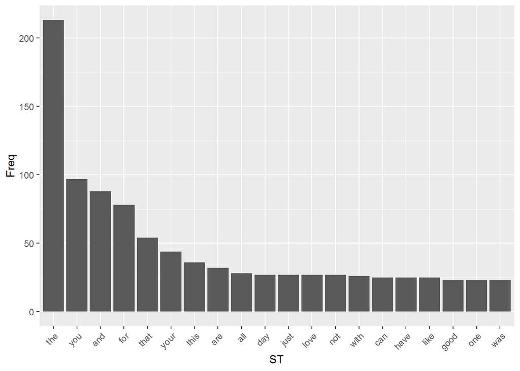

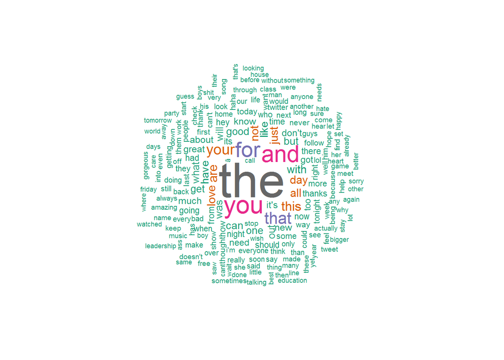

```r
# 2-gram
ng2TDM <- TDM(corpus, min_ngram=2, max_ngram=2)
ng2Freq <- word_freqs(ng2TDM)
term_summary(ng2TDM, ng2Freq)
```

```
## [1] "number of terms:  4827"
## [1] "freqs:  c(1325, 1920, 4161, 2819, 2887, 1810, 3681, 1476, 41, 1796, 4080, 39, 1288, 1838, 1967, 2654, 3463, 265, 376, 426)"
## [2] "freqs:  c(19, 18, 15, 13, 11, 10, 10, 9, 8, 8, 8, 7, 7, 7, 7, 7, 7, 6, 6, 6)"
```

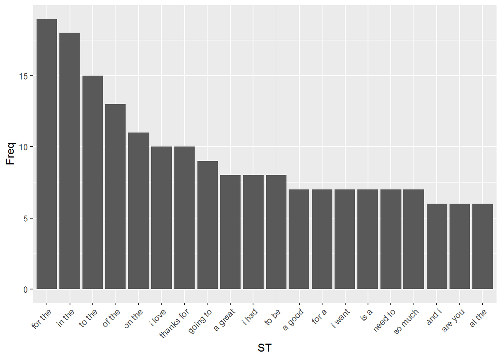

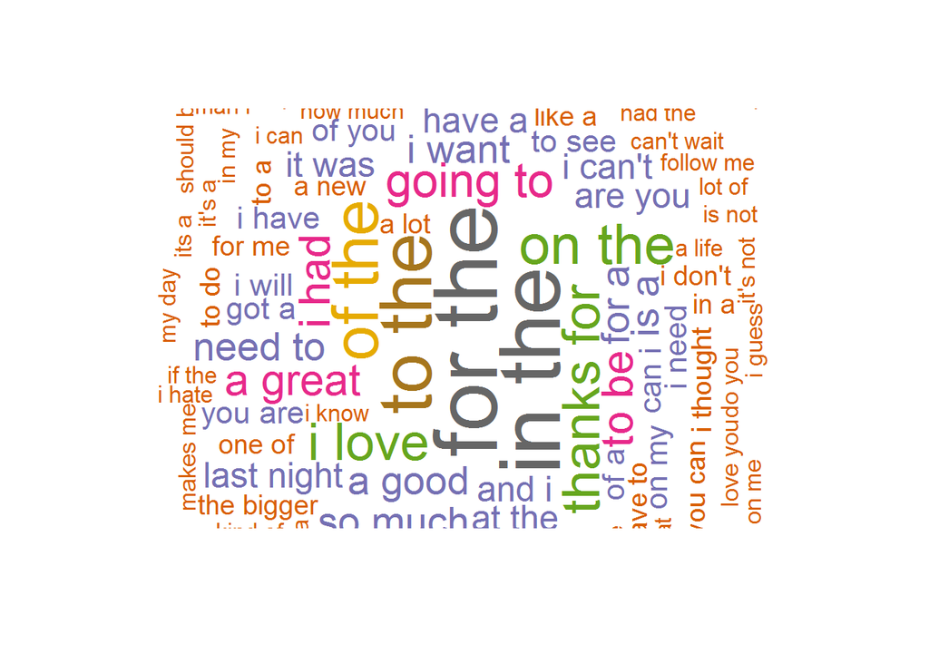

# Do the same for the blogs data

```r
corpus <- create_corpus(dir="data/en_US/", filename="sample_en_US.blogs.txt", read_chunk=50)
strwrap(corpus[[1]]) # print contents
```

```
## [1] "in the years thereafter most of the oil fields and platforms were"
## [2] "named after pagangodsâ\235"
```

```r
print(paste("number of lines: ",length(corpus))) # documents are lines
```

```
## [1] "number of lines:  6000"
```

```r
# bag of words
wordTDM <- TDM(corpus)
wordFreq <- word_freqs(wordTDM)
term_summary(wordTDM, wordFreq)
```

```
## [1] "number of terms:  5315"
## [1] "freqs:  c(4697, 169, 4692, 1824, 5209, 5089, 5298, 4738, 2122, 648, 3138, 252, 128, 2678, 1882, 2163, 4723, 2500, 3206, 4716)"
## [2] "freqs:  c(1036, 631, 295, 209, 189, 178, 167, 142, 132, 121, 94, 92, 85, 76, 74, 72, 72, 71, 70, 69)"
```

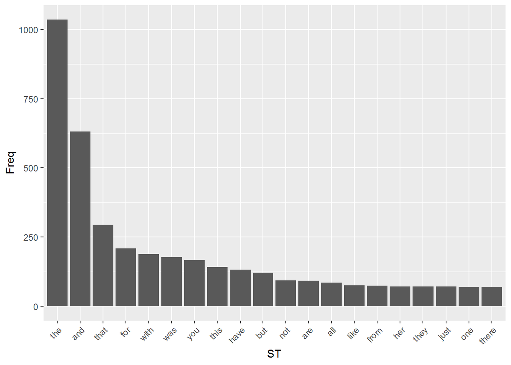

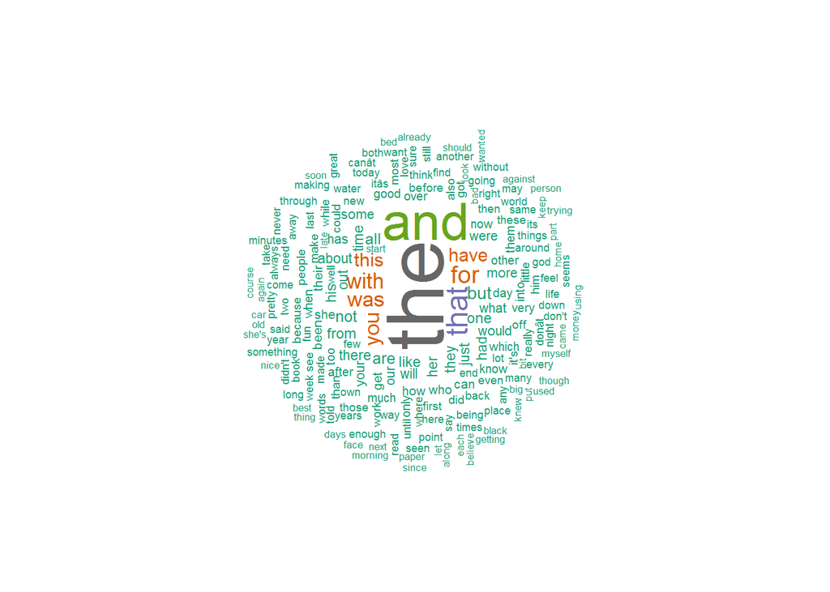

```r
# 2-gram
ng2TDM <- TDM(corpus, min_ngram=2, max_ngram=2)
ng2Freq <- word_freqs(ng2TDM)
term_summary(ng2TDM, ng2Freq)
```

```
## [1] "number of terms:  16268"
## [1] "freqs:  c(9327, 6686, 14318, 9514, 1059, 14049, 7128, 6445, 6565, 4922, 15821, 1705, 1244, 6334, 12610, 6335, 7081, 9125, 2515, 6260)"
## [2] "freqs:  c(86, 81, 51, 45, 42, 40, 35, 33, 32, 31, 30, 28, 27, 26, 26, 25, 25, 23, 22, 22)"
```

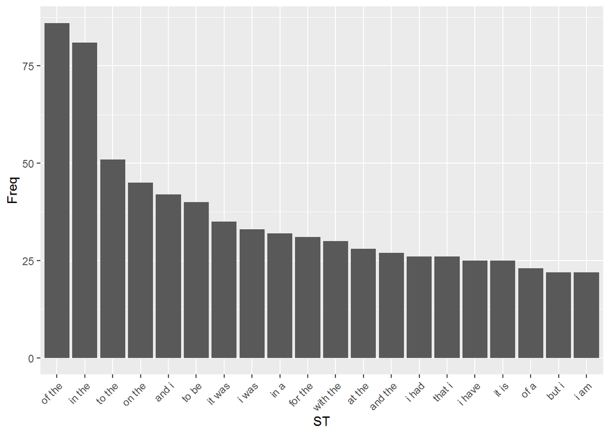

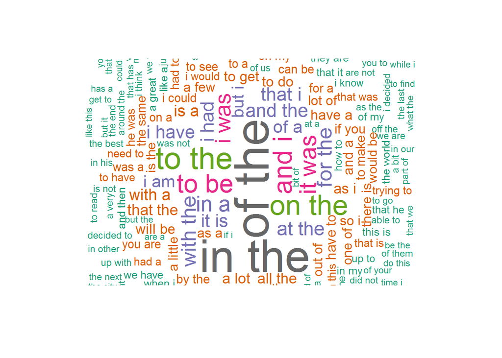

# Do the same for the news data

```r
corpus <- create_corpus(dir="data/en_US/", filename="sample_en_US.news.txt", read_chunk=50)
strwrap(corpus[[1]]) # print contents
```

```
## [1] "he wasn't home alone apparently"
```

```r
print(paste("number of lines: ",length(corpus))) # documents are lines
```

```
## [1] "number of lines:  6000"
```

```r
# bag of words
wordTDM <- TDM(corpus)
wordFreq <- word_freqs(wordTDM)
term_summary(wordTDM, wordFreq)
```

```
## [1] "number of terms:  4982"
## [1] "freqs:  c(4413, 183, 1734, 4407, 3784, 4891, 4786, 636, 2061, 2945, 1784, 255, 1988, 2827, 4434, 4446, 1981, 2914, 4963, 4857)"
## [2] "freqs:  c(936, 411, 181, 166, 141, 138, 106, 90, 83, 76, 73, 70, 68, 62, 56, 53, 51, 49, 49, 48)"
```

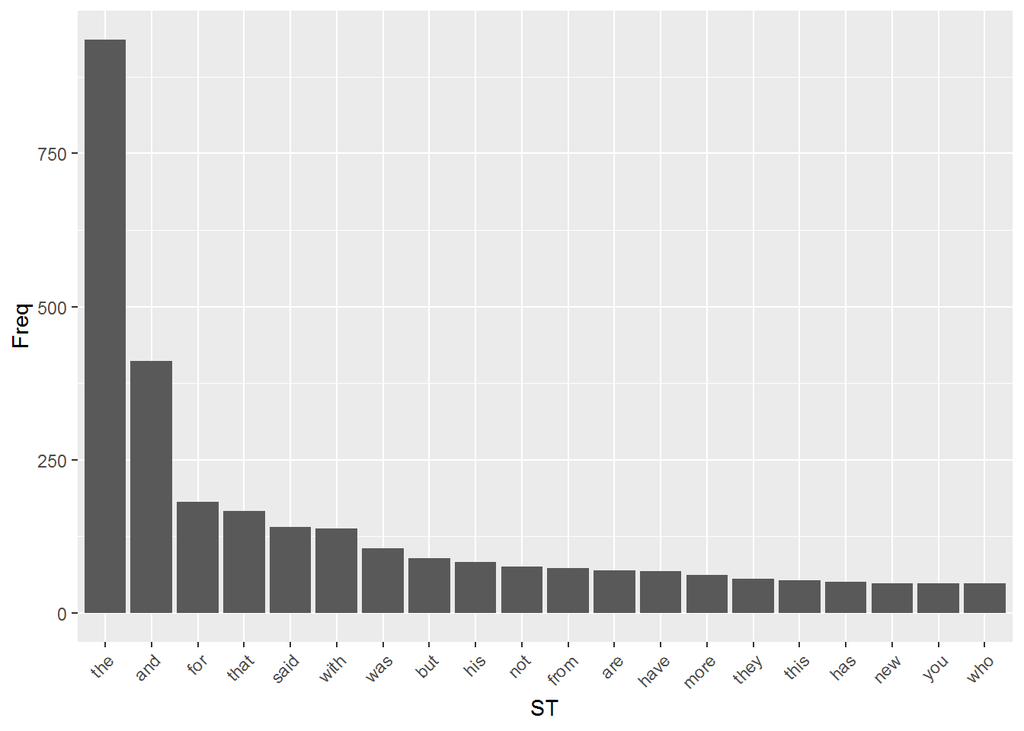

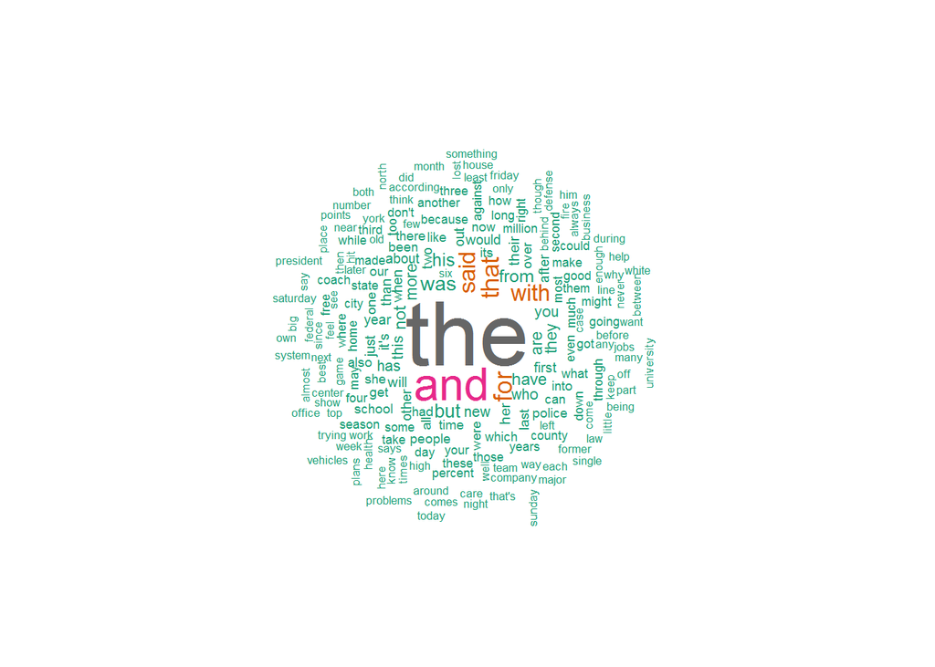

```r
# 2-gram
ng2TDM <- TDM(corpus, min_ngram=2, max_ngram=2)
ng2Freq <- word_freqs(ng2TDM)
term_summary(ng2TDM, ng2Freq)
```

```
## [1] "number of terms:  13359"
## [1] "freqs:  c(7695, 5547, 4176, 7866, 11934, 5399, 11701, 1054, 1468, 4330, 4867, 7514, 13051, 7084, 10606, 9305, 11680, 10869, 2200, 4087)"
## [2] "freqs:  c(85, 73, 35, 34, 34, 27, 27, 25, 25, 23, 21, 21, 21, 18, 18, 17, 17, 16, 15, 15)"
```

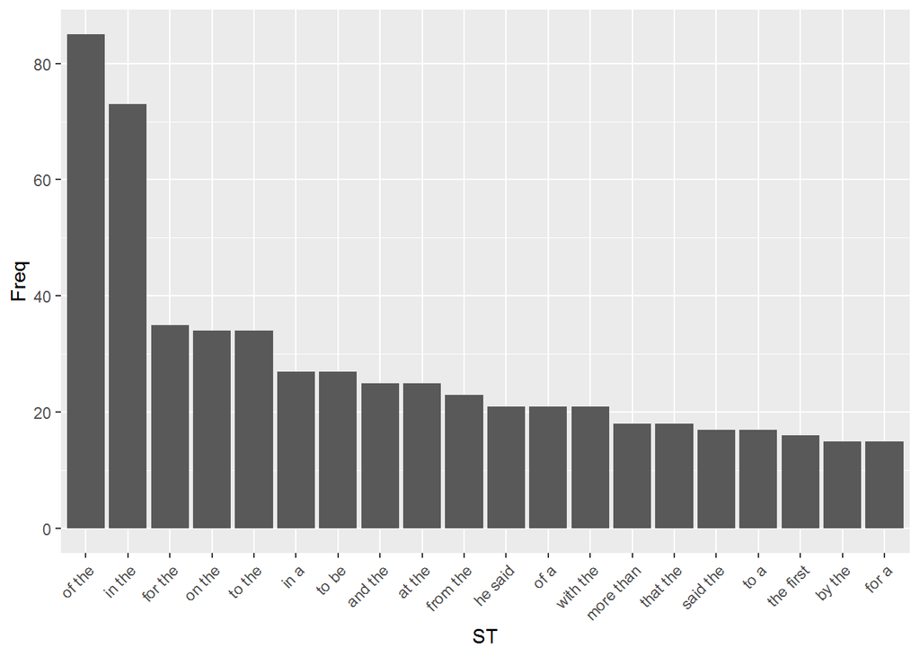

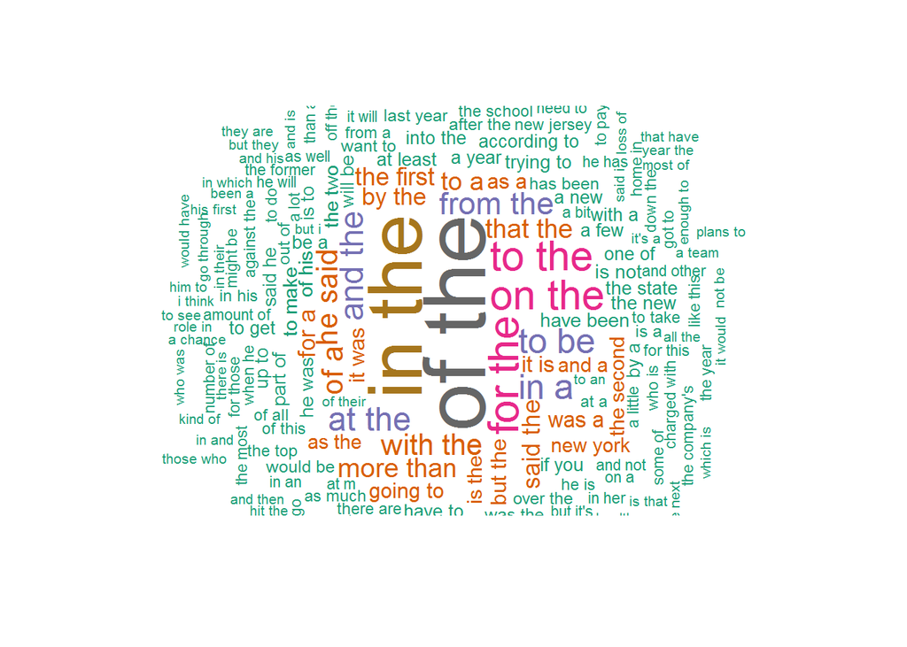